# EXPLORATORY DATA ANALYSIS

## SPLENDOR ANALYTICS AUTO INSURANCE EXPLORATORY DATA ANALYSIS

```python
# pip install pandas
```

```python
import pandas as pd
```

```python
import matplotlib.pyplot as plt
import seaborn as sns
```

```python
import scipy.stats as stats
```

```python
# load the dataset
```

```python
df = pd.read_excel('Insurance Policies.xlsx', sheet_name= 'Clean Insurance Policies')
```

#### We answer some questions of the data to gain more insights

#### 1. What are the average claim frequencies and amounts for different demographic groups (e.g., gender, marital status, education etc)?

```python
#Group by 'gender'
avg_claims_by_gender = df.groupby('gender').agg(
    avg_claim_freq=('claim_freq', 'mean'),
    avg_claim_amt=('claim_amt', 'mean')
).reset_index()

print('Average Claims by Gender: ')
print(avg_claims_by_gender)


# Group by 'marital_status'
avg_claims_by_marital_status = df.groupby('marital_status').agg(
    avg_claim_freq=('claim_freq', 'mean'),
    avg_claim_amt=('claim_amt', 'mean')
).reset_index()

print("Average Claims by Marital Status: ")
print(avg_claims_by_marital_status)


# Group by 'education'
avg_claims_by_education = df.groupby('education').agg(
    avg_claim_freq=('claim_freq', 'mean'),
    avg_claim_amt=('claim_amt', 'mean')
).reset_index()

print("Average Claims by Education: ")
print(avg_claims_by_education)


# Group by 'car_use'
avg_claims_by_car_use = df.groupby('car_use').agg(
    avg_claim_freq=('claim_freq', 'mean'),
    avg_claim_amt=('claim_amt', 'mean')
).reset_index()

print("Average Claims by Car Use: ")
print(avg_claims_by_car_use)


# Group by 'parent'
avg_claims_by_parent = df.groupby('parent').agg(
    avg_claim_freq=('claim_freq', 'mean'),
    avg_claim_amt=('claim_amt', 'mean')
).reset_index()

print("Average Claims by Parent: ")
print(avg_claims_by_parent)


# Group by 'coverage_zone'
avg_claims_by_coverage_zone = df.groupby('coverage_zone').agg(
    avg_claim_freq=('claim_freq', 'mean'),
    avg_claim_amt=('claim_amt', 'mean')
).reset_index()

print("Average Claims by Coverage Zone: ")
print(avg_claims_by_coverage_zone)
```

```
Average Claims by Gender:
   gender  avg_claim_freq  avg_claim_amt
0  Female        0.514357   49860.058201
1    Male        0.506245   50197.599363
Average Claims by Marital Status:
  marital_status  avg_claim_freq  avg_claim_amt
0       Divorced        0.492213   50089.164486
1        Married        0.520286   50337.818821
2      Seperated        0.533657   49259.423023
3         Single        0.504992   49906.322566
Average Claims by Education:
     education  avg_claim_freq  avg_claim_amt
0    Bachelors        0.507994   50275.535654
1  High School        0.514800   49621.538801
2      Masters        0.514539   50193.972149
3          PhD        0.500362   49556.277143
Average Claims by Car Use:
      car_use  avg_claim_freq  avg_claim_amt
0  Commercial        0.498663   50005.247874
1     Private        0.513207   50034.305110
Average Claims by Parent:
  parent  avg_claim_freq  avg_claim_amt
0     No        0.510032   50084.902634
1    Yes        0.510656   49957.452996
Average Claims by Coverage Zone:
  coverage_zone  avg_claim_freq  avg_claim_amt
0  Highly Rural        0.500403   49998.132178
1  Highly Urban        0.516503   49861.036665
2         Rural        0.506381   49778.020247
3      Suburban        0.520091   50124.843185
4         Urban        0.508171   50377.730389
```

#### 2. Are there any specific vehicle characteristics (e.g., make, model and year) that correlate with higher claim frequencies or amounts?

##### for Car Year

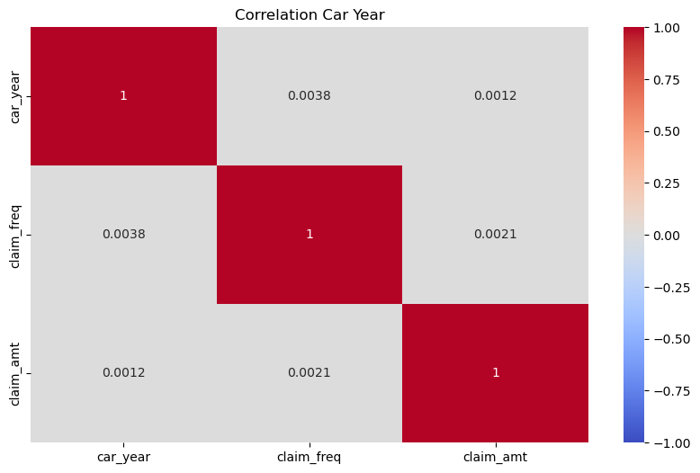

```python
# Calculate correlation matrix for vehicle characteristics and claim metrics

vehicle_year = df[['car_year', 'claim_freq', 'claim_amt']]
correlation_year = vehicle_year.corr()


# Correlation heatmap
plt.figure(figsize=(10, 6))
sns.heatmap(correlation_year, annot=True, cmap='coolwarm', vmin=-1, vmax=1)
plt.title('Correlation Car Year')
plt.show()
```

There is no correlation between the car year, claim frequency, and claim amount

##### For Car Make

```python
# Define a function to calculate chi-square for categorical variables
def chi_square_test(df, column, target):
    contingency_table = pd.crosstab(df[column], df[target]>df[target].median())
    chi2, p, dof, expected = stats.chi2_contingency(contingency_table)
    return chi2, p

# Apply chi-square test for 'car_make' and 'car_model'

chi2_car_make_freq, p_car_make_freq = chi_square_test(df, 'car_make', 'claim_freq')
chi2_car_make_amt, p_car_make_amt = chi_square_test(df, 'car_make', 'claim_amt')
chi2_car_model_freq, p_car_model_freq = chi_square_test(df, 'car_model', 'claim_freq')
chi2_car_model_amt, p_car_model_amt = chi_square_test(df, 'car_model', 'claim_amt')

print(f"Chi-square test for car make frequeny claim: chi2={chi2_car_make_freq}, p-value={p_car_make_freq}")
print(f"Chi-square test for car make amount claim: chi2={chi2_car_make_amt}, p-value={p_car_make_amt}")
print(f"Chi-square test for car model frequency claim: chi2={chi2_car_model_freq}, p-value={p_car_model_freq}")
print(f"Chi-square test for car model amount claim: chi2={chi2_car_model_amt}, p-value={p_car_model_amt}")

# Calculate the critical value

alpha = 0.05
shape = 563115
critical_value = stats.chi2.ppf(1 - alpha, shape)
print(f'Critical value for the Chi-square test = {critical_value}')
```

```
Chi-square test for car make frequeny claim: chi2=79.99070199786641, p-value=0.38532311019225357
Chi-square test for car make amount claim: chi2=91.09506115545324, p-value=0.1300698159338125
Chi-square test for car model frequency claim: chi2=1046.119708949842, p-value=0.20924088645771335
Chi-square test for car model amount claim: chi2=1038.0584158331842, p-value=0.2632355110760711
Critical value for the Chi-square test = 564861.7204906178
```

The Chi-square is lower than the critical value hence, there is no correlation Likewise, the p-value is higher than 0.05 hence, there is no correlation

#### 3. What are the key characteristics of policyholders with low claim frequencies and high household incomes?

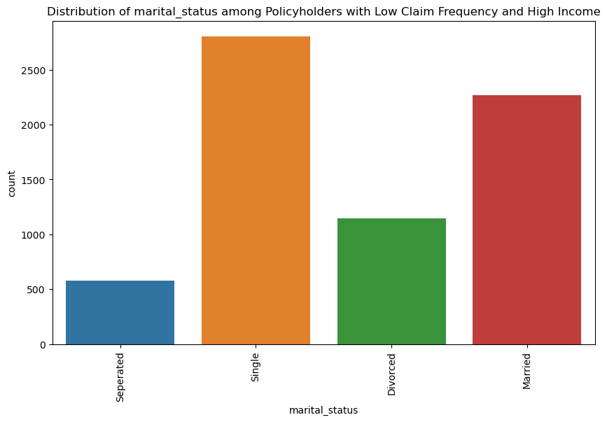

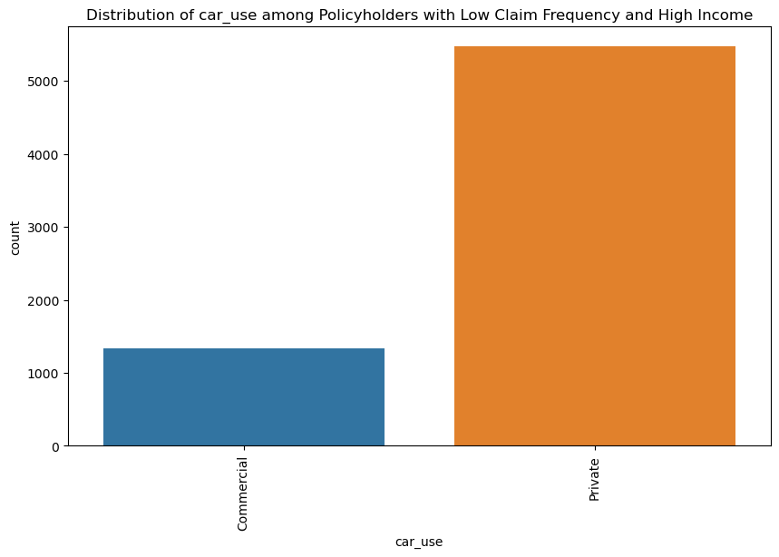

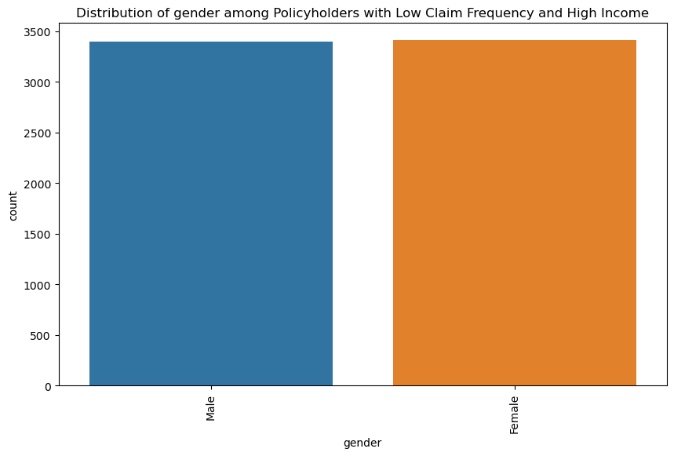

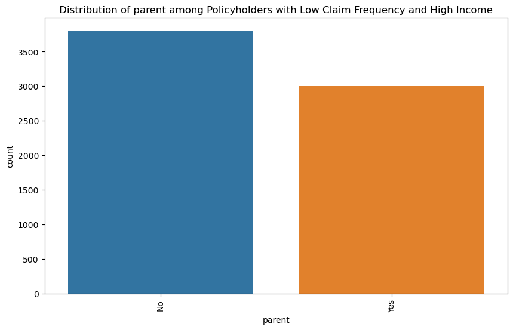

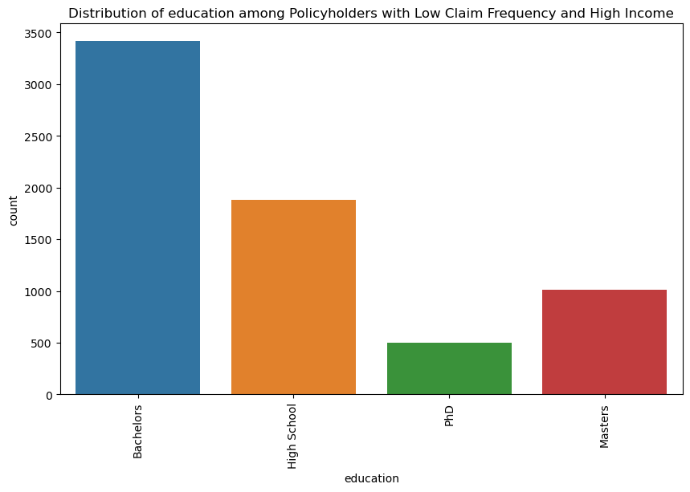

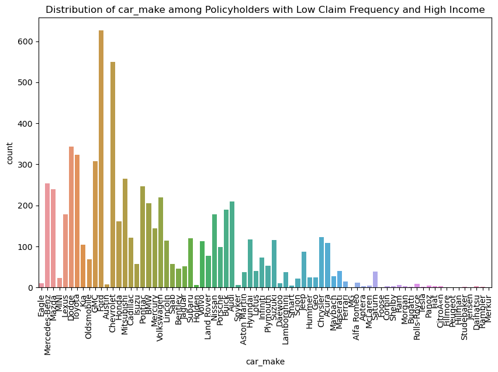

[figure not shown]

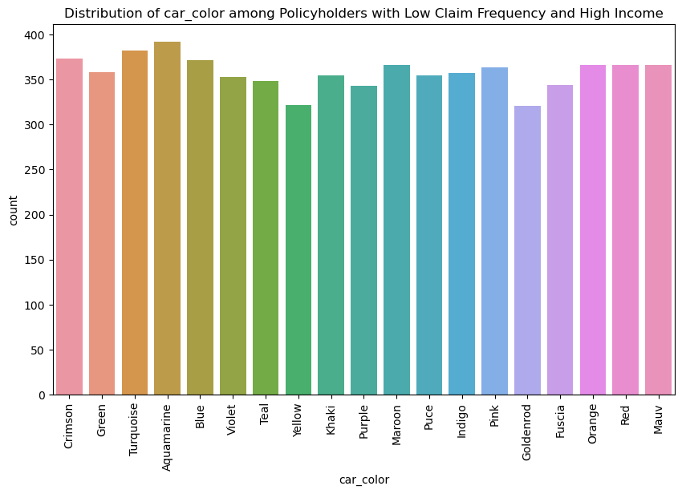

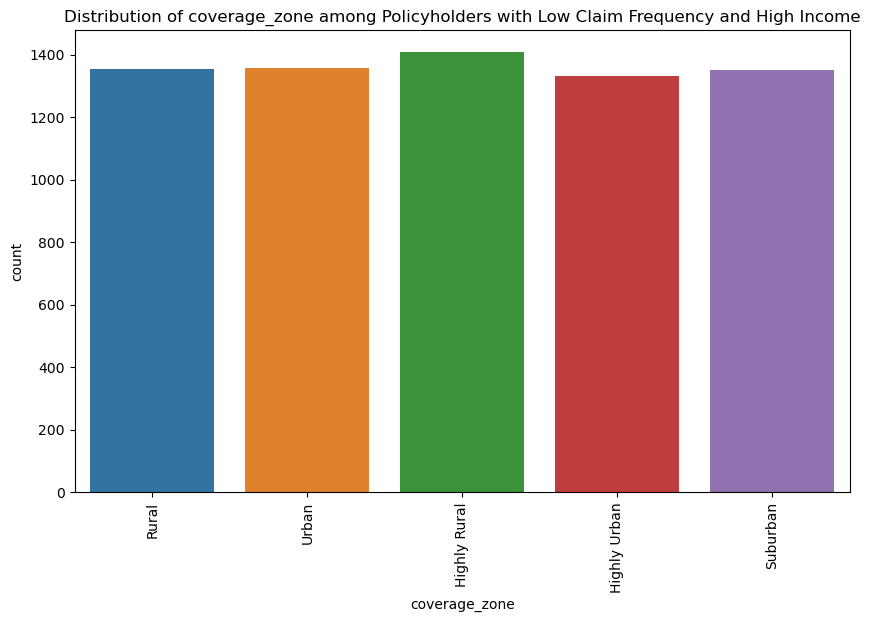

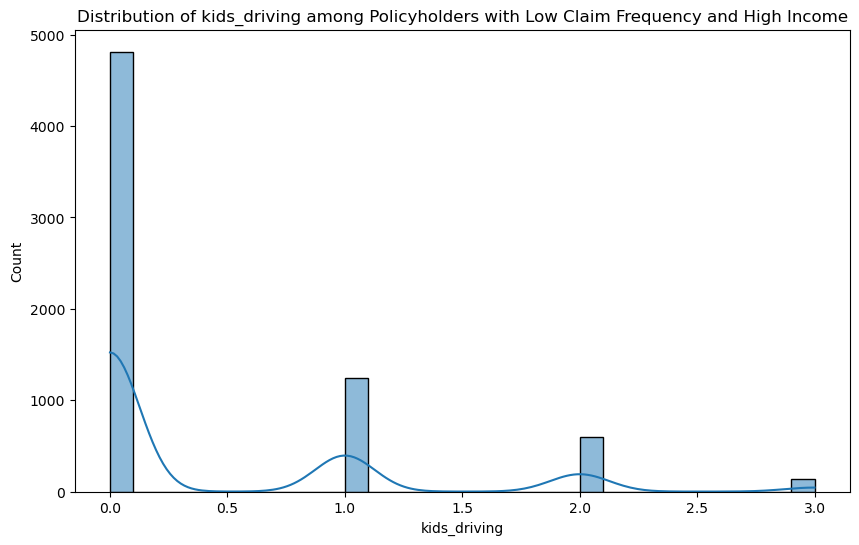

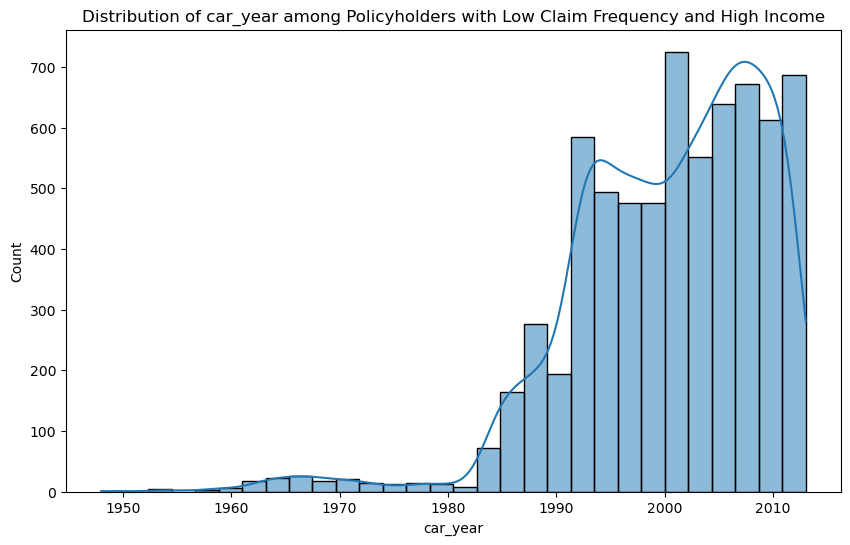

```python
# Define thresholds
low_claim_freq_threshold = df['claim_freq'].quantile(0.25)
high_income_threshold = df['household_income'].quantile(0.75)

# Filter policyholders with low claim frequencies and high household incomes
low_claim_high_income = df[(df['claim_freq'] <= low_claim_freq_threshold) & (df['household_income'] >= high_income_threshold)]


# Distribution of key categorical characteristics
categorical_vars = ['marital_status', 'car_use', 'gender', 'parent', 'education', 'car_make', 'car_model', 'car_color',
                    'coverage_zone']

for var in categorical_vars:
    plt.figure(figsize=(10, 6))
    sns.countplot(x=low_claim_high_income[var])
    plt.title(f'Distribution of {var} among Policyholders with Low Claim Frequency and High Income')
    plt.xticks(rotation=90)
    plt.show()

# Distribution of key numerical characteristics
numerical_vars = ['kids_driving', 'car_year']

for var in numerical_vars:
    plt.figure(figsize=(10, 6))
    sns.histplot(low_claim_high_income[var], bins=30, kde=True)
    plt.title(f'Distribution of {var} among Policyholders with Low Claim Frequency and High Income')
    plt.show()
```

The percentage distribution were the same with the descriptive statistics except for coverage zone where highly rural has a higher percentage.

#### 4. How does the distribution of policyholders vary across different demographic factors (age, gender, marital status)?

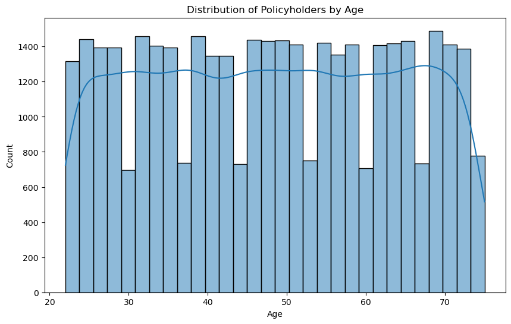

```
Age Statistics:
count    37542.000000
mean        48.153721
std         15.295082
min         22.000000
25%         35.000000
50%         48.000000
75%         61.000000
max         75.000000
Name: age, dtype: float64
```

```python
# Convert birthdate to age
df['birthdate'] = pd.to_datetime(df['birthdate'])
current_year = pd.to_datetime('today').year
df['age'] = current_year - df['birthdate'].dt.year



# Plot age distribution
plt.figure(figsize=(10, 6))
sns.histplot(df['age'], bins=30, kde=True)
plt.title('Distribution of Policyholders by Age')
plt.xlabel('Age')
plt.ylabel('Count')
plt.show()


# Summary statistics for age
age_stats = df['age'].describe()
print('Age Statistics:')
print(age_stats)
```

Each decade in the range of 20 < age > 80 is properly distributed

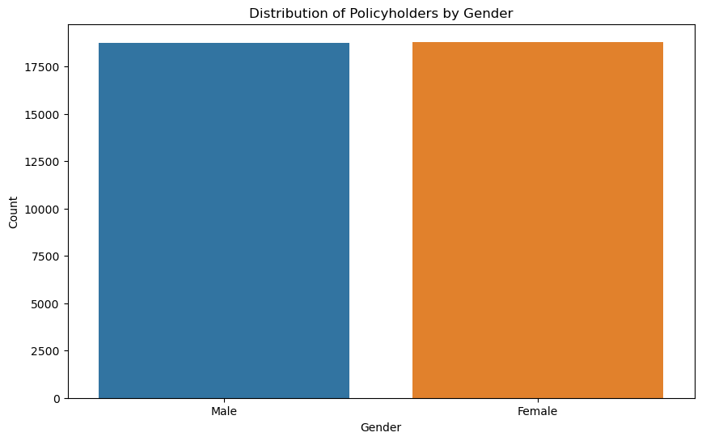

```
Gender Distribution (Percentage):
gender
Female    50.093229
Male      49.906771
Name: proportion, dtype: float64
```

```python
# Plot gender distribution
plt.figure(figsize=(10, 6))
sns.countplot(x=df['gender'])
plt.title('Distribution of Policyholders by Gender')
plt.xlabel('Gender')
plt.ylabel('Count')
plt.show()


# Summary statistics for gender
gender_stats = df['gender'].value_counts(normalize=True) * 100
print('Gender Distribution (Percentage):')
print(gender_stats)
```

Both genders are almost equal in distribution

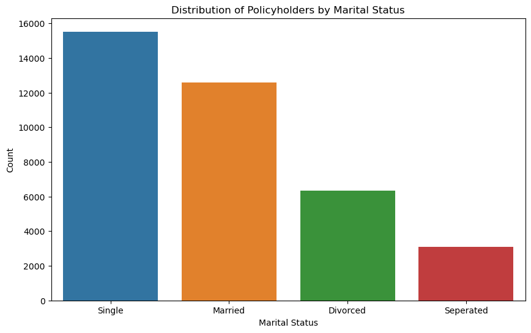

```
Marital Status Distribution (Percentage):
marital_status
Single       41.353684
Married      33.482500
Divorced     16.933035
Seperated     8.230782
Name: proportion, dtype: float64
```

```python
# Plot marital status distribution
plt.figure(figsize=(10, 6))
sns.countplot(x=df['marital_status'])
plt.title('Distribution of Policyholders by Marital Status')
plt.xlabel('Marital Status')
plt.ylabel('Count')
plt.show()


# Summary statistics for marital status
marital_status_stats = df['marital_status'].value_counts(normalize=True) * 100
print('Marital Status Distribution (Percentage):')
print(marital_status_stats)
```

There is a significantly higher percentage of single and married marital status

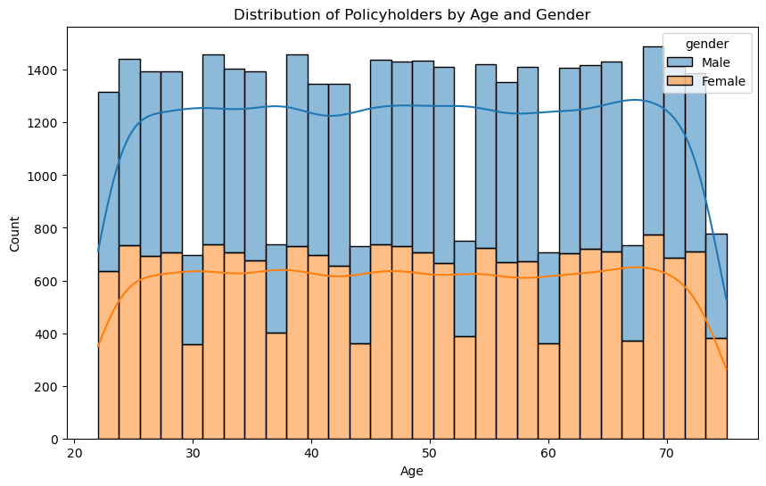

```python
# Plot age distribution by gender
plt.figure(figsize=(10, 6))
sns.histplot(data=df, x='age', hue='gender', bins=30, kde=True, multiple="stack")
plt.title('Distribution of Policyholders by Age and Gender')
plt.xlabel('Age')
plt.ylabel('Count')
plt.show()
```

The genders are evenly distributed across all ages

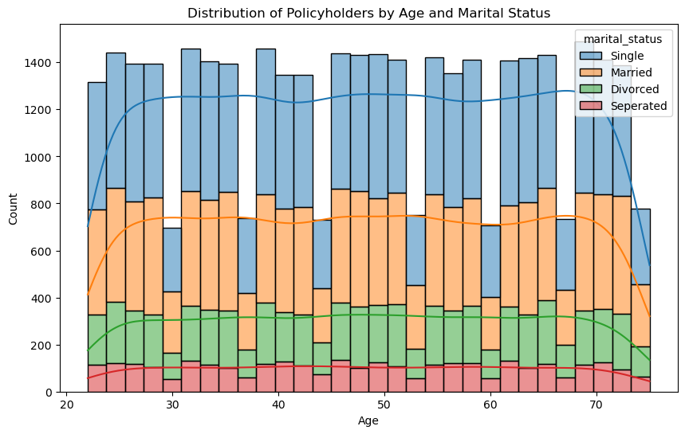

```python
# Plot age distribution by marital status
plt.figure(figsize=(10, 6))
sns.histplot(data=df, x='age', hue='marital_status', bins=30, kde=True, multiple="stack")
plt.title('Distribution of Policyholders by Age and Marital Status')
plt.xlabel('Age')
plt.ylabel('Count')
plt.show()
```

The trend on the marital status is equally distrubuted across all ages

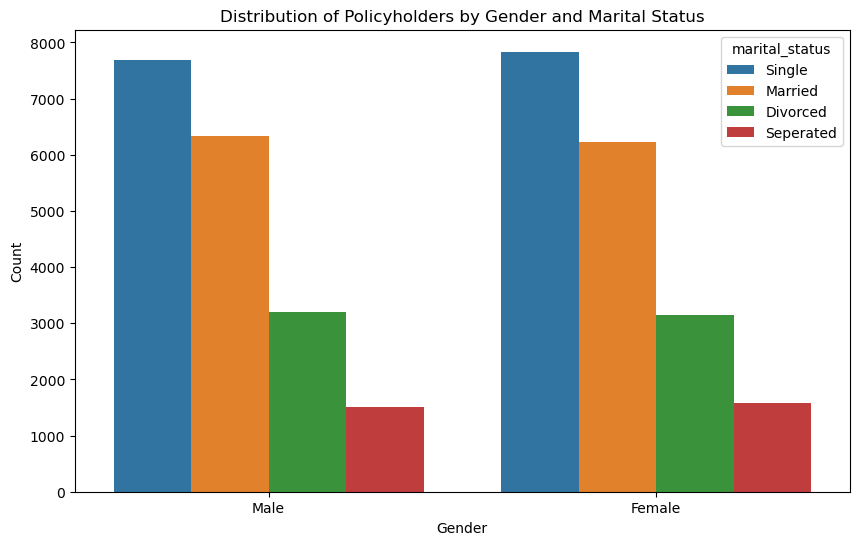

```python
# Plot gender distribution by marital status
plt.figure(figsize=(10, 6))
sns.countplot(x='gender', hue='marital_status', data=df)
plt.title('Distribution of Policyholders by Gender and Marital Status')
plt.xlabel('Gender')
plt.ylabel('Count')
plt.show()
```

The trend across the marital status is evenly distributed across all genders

#### 5. Are there any noticeable trends in car usage and ownership among different demographic groups?

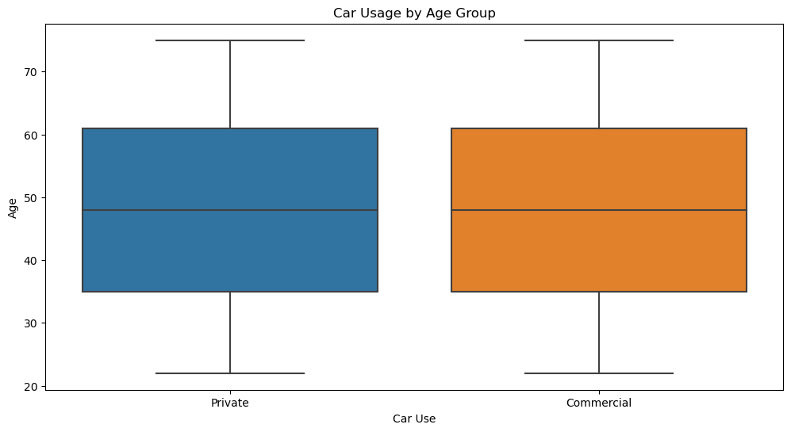

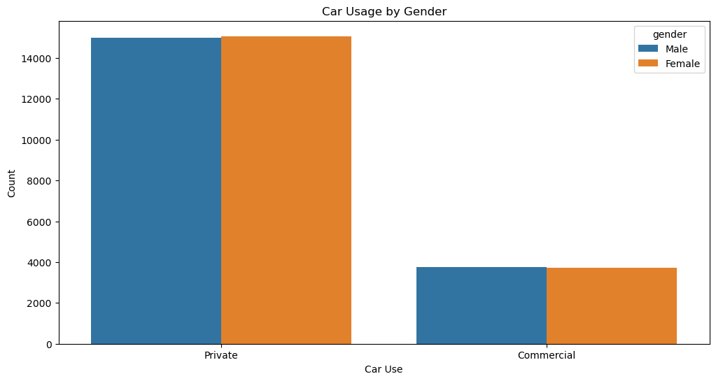

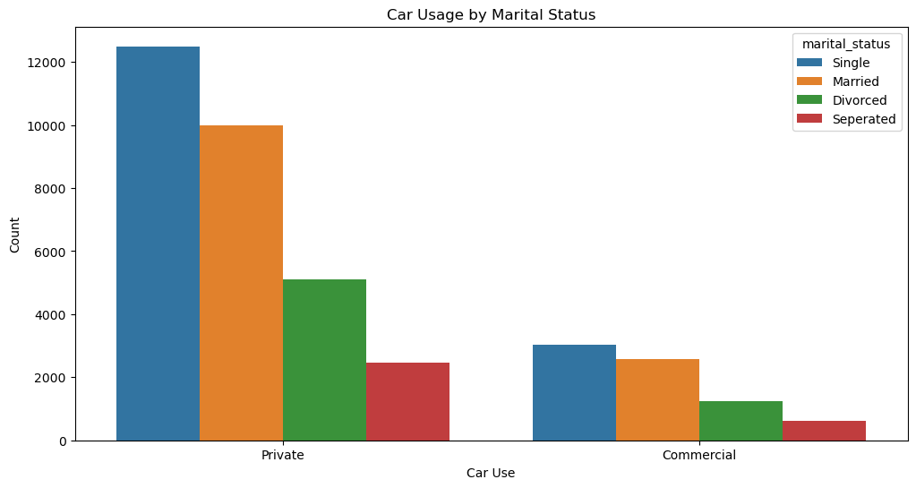

```python
#Car usage by demographic group



# Plot car usage by age group
plt.figure(figsize=(12, 6))
sns.boxplot(x='car_use', y='age', data=df)
plt.title('Car Usage by Age Group')
plt.xlabel('Car Use')
plt.ylabel('Age')
plt.show()

# Plot car usage by gender
plt.figure(figsize=(12, 6))
sns.countplot(x='car_use', hue='gender', data=df)
plt.title('Car Usage by Gender')
plt.xlabel('Car Use')
plt.ylabel('Count')
plt.show()

# Plot car usage by marital status
plt.figure(figsize=(12, 6))
sns.countplot(x='car_use', hue='marital_status', data=df)
plt.title('Car Usage by Marital Status')
plt.xlabel('Car Use')
plt.ylabel('Count')
plt.show()
```

Car usage by demographic group are evenly distributed

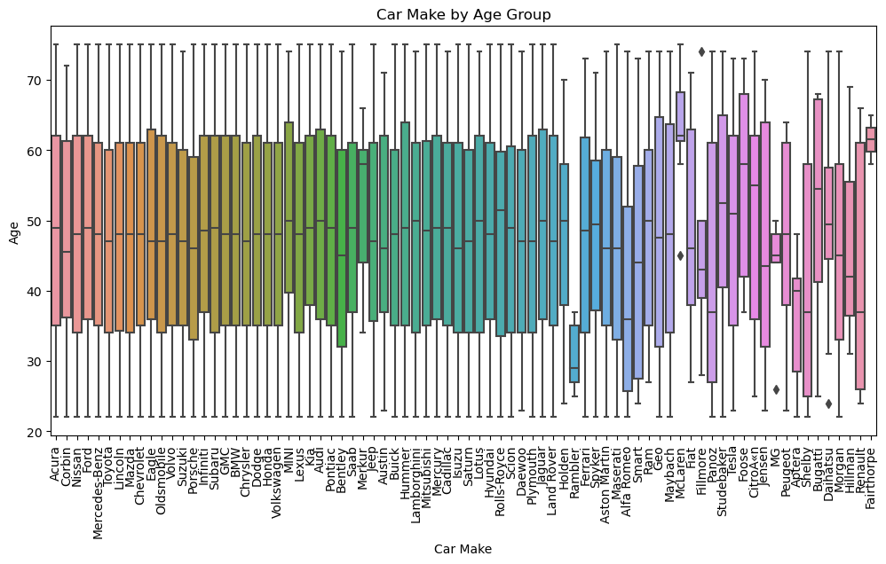

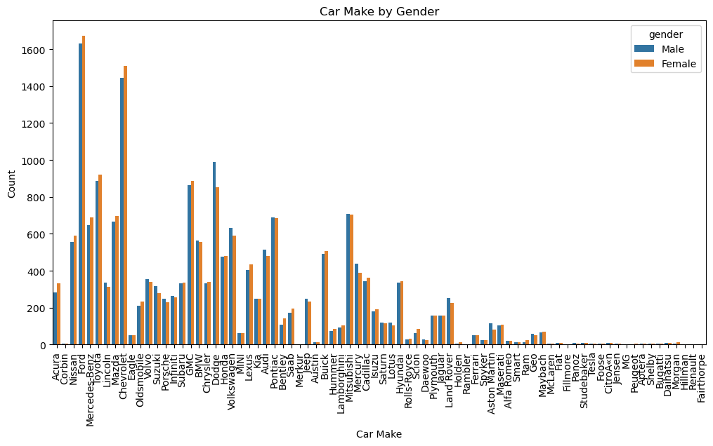

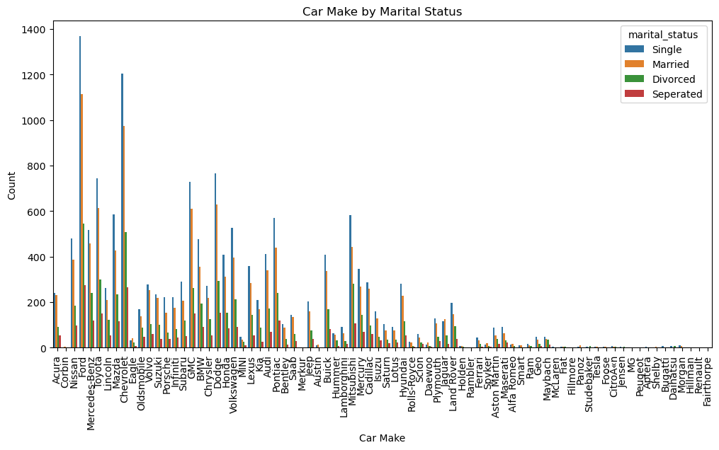

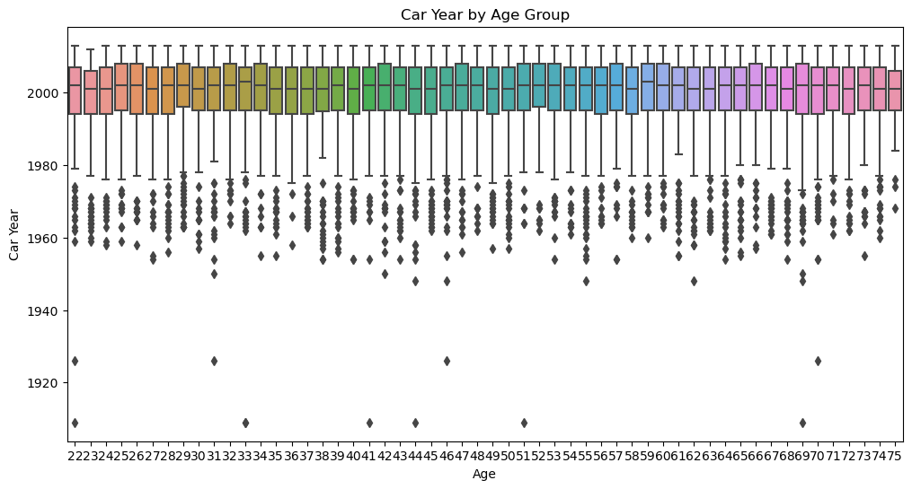

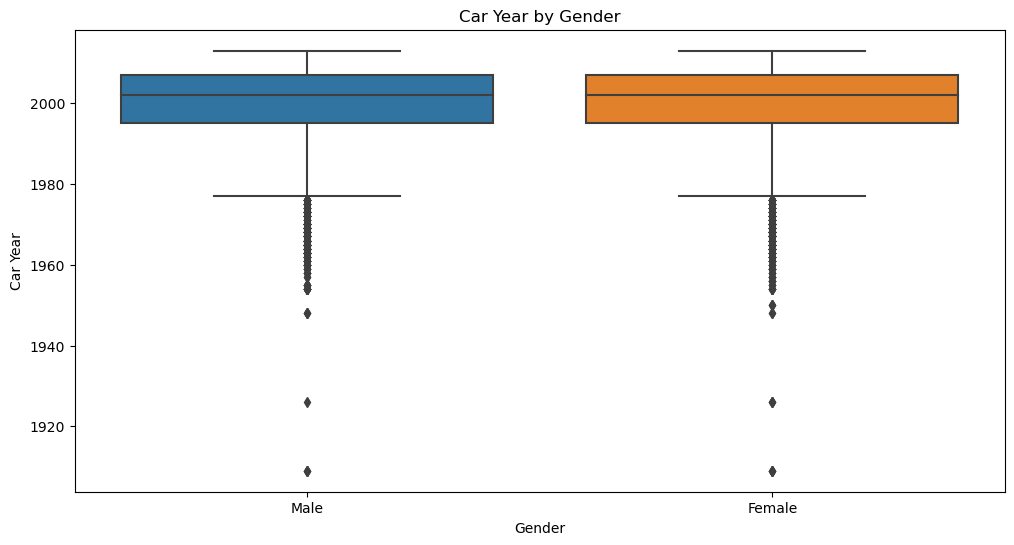

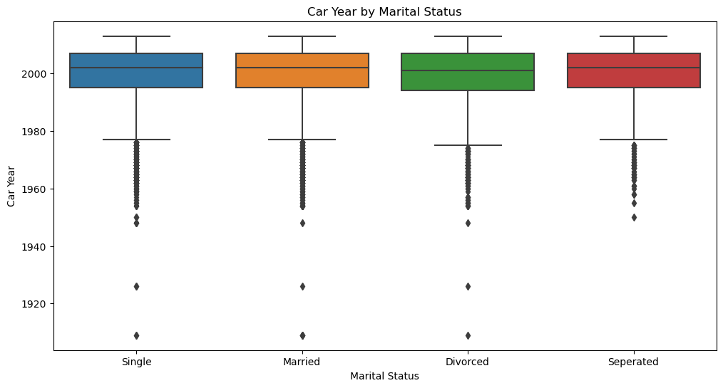

```python
#Car ownership by demographic group


# Plot car make by age group
plt.figure(figsize=(12, 6))
sns.boxplot(x='car_make', y='age', data=df)
plt.title('Car Make by Age Group')
plt.xlabel('Car Make')
plt.ylabel('Age')
plt.xticks(rotation=90)
plt.show()

# Plot car make by gender
plt.figure(figsize=(12, 6))
sns.countplot(x='car_make', hue='gender', data=df)
plt.title('Car Make by Gender')
plt.xlabel('Car Make')
plt.ylabel('Count')
plt.xticks(rotation=90)
plt.show()

# Plot car make by marital status
plt.figure(figsize=(12, 6))
sns.countplot(x='car_make', hue='marital_status', data=df)
plt.title('Car Make by Marital Status')
plt.xlabel('Car Make')
plt.ylabel('Count')
plt.xticks(rotation=90)
plt.show()

# Plot car year by age group
plt.figure(figsize=(12, 6))
sns.boxplot(x='age', y='car_year', data=df)
plt.title('Car Year by Age Group')
plt.xlabel('Age')
plt.ylabel('Car Year')
plt.show()

# Plot car year by gender
plt.figure(figsize=(12, 6))
sns.boxplot(x='gender', y='car_year', data=df)
plt.title('Car Year by Gender')
plt.xlabel('Gender')
plt.ylabel('Car Year')
plt.show()

# Plot car year by marital status
plt.figure(figsize=(12, 6))
sns.boxplot(x='marital_status', y='car_year', data=df)
plt.title('Car Year by Marital Status')
plt.xlabel('Marital Status')
plt.ylabel('Car Year')
plt.show()
```

Majority of the car make are evenly distributed across the age group

There are very little changes in the choice of car make across the different genders

The trend in the marital status is also reflected in the choice of a car make

majority of the age group prefer cars made in the 2000s

There is an equal distribution in the car year across the genders

The car year below the 1940s were common among the marital status with the exception of the separated

#### 6. How do claim frequencies and amounts vary across different coverage zones?

```python
#Summary statistics by coverage zone

# Group by coverage zone and calculate summary statistics
coverage_zone_stats = df.groupby('coverage_zone').agg({
    'claim_freq': ['mean', 'median', 'std', 'min', 'max'],
    'claim_amt': ['mean', 'median', 'std', 'min', 'max']
}).reset_index()

# Rename columns for clarity
coverage_zone_stats.columns = ['coverage_zone', 'mean_claim_freq', 'median_claim_freq', 'std_claim_freq', 'min_claim_freq',
                               'max_claim_freq', 'mean_claim_amt', 'median_claim_amt', 'std_claim_amt', 'min_claim_amt',
                               'max_claim_amt']

print(coverage_zone_stats)
```

```
  coverage_zone  mean_claim_freq  median_claim_freq  std_claim_freq  \
0  Highly Rural         0.500403                0.0        1.006821
1  Highly Urban         0.516503                0.0        1.017513
2         Rural         0.506381                0.0        1.011711
3      Suburban         0.520091                0.0        1.032330
4         Urban         0.508171                0.0        1.006928

   min_claim_freq  max_claim_freq  mean_claim_amt  median_claim_amt  \
0               0               4    49998.132178         49247.505
1               0               4    49861.036665         49591.315
2               0               4    49778.020247         49018.085
3               0               4    50124.843185         49634.210
4               0               4    50377.730389         49953.310

   std_claim_amt  min_claim_amt  max_claim_amt
0   28533.980796          19.70       99997.70
1   28883.692225          83.42       99993.70
2   28804.337193          22.56       99980.29
3   28669.617026          22.00       99994.03
4   28642.245078           0.04       99975.60
```

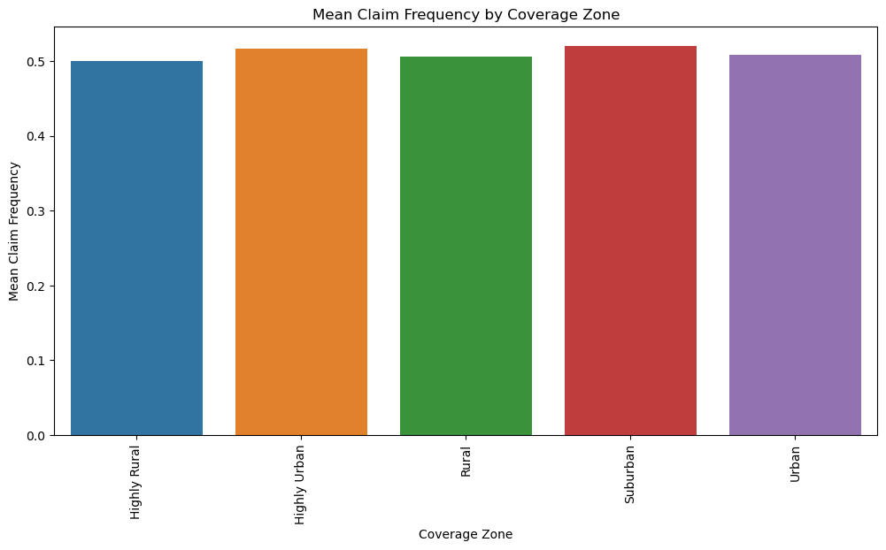

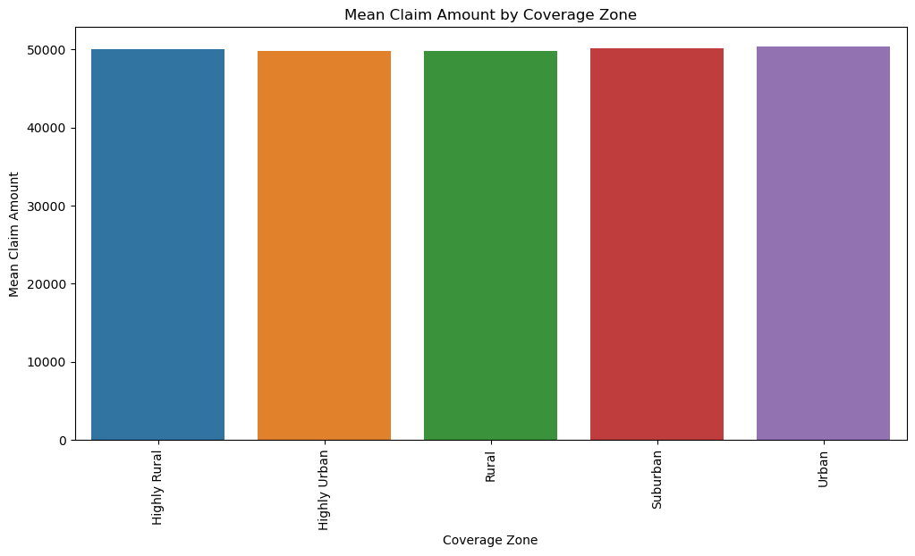

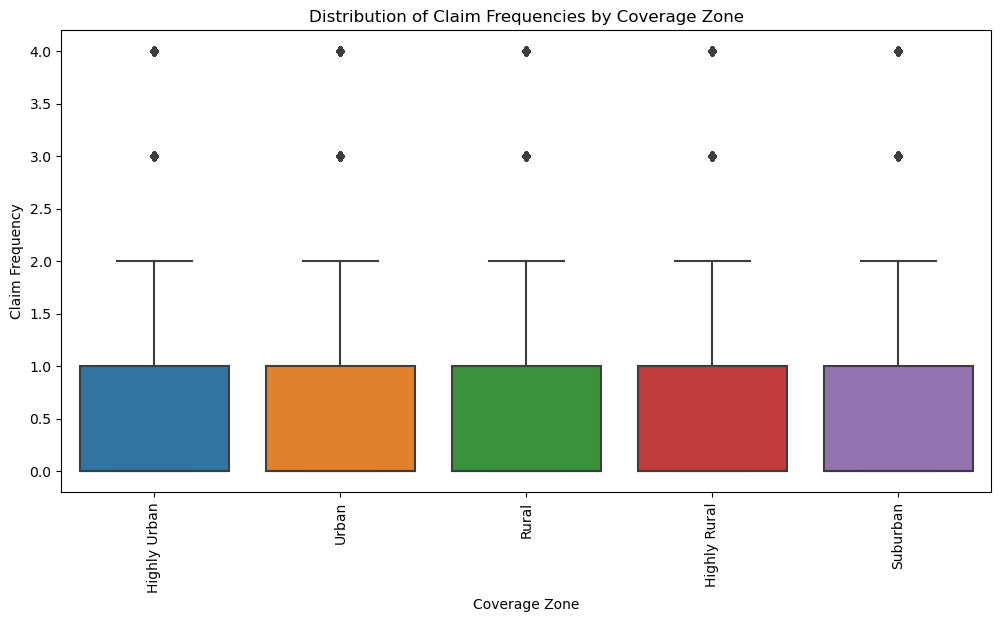

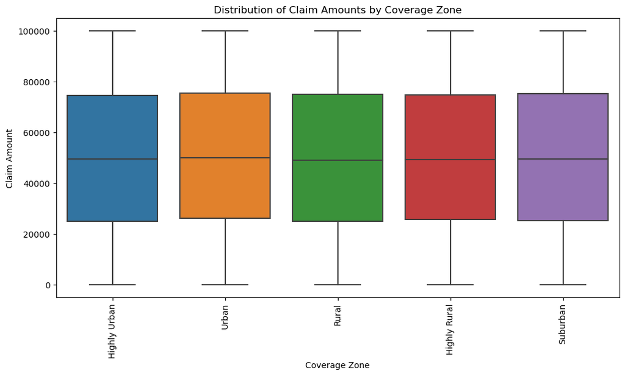

```python
#Visualization of the distribution


# Plot mean claim frequency by coverage zone
plt.figure(figsize=(12, 6))
sns.barplot(x='coverage_zone', y='mean_claim_freq', data=coverage_zone_stats)
plt.title('Mean Claim Frequency by Coverage Zone')
plt.xlabel('Coverage Zone')
plt.ylabel('Mean Claim Frequency')
plt.xticks(rotation=90)
plt.show()

# Plot mean claim amount by coverage zone
plt.figure(figsize=(12, 6))
sns.barplot(x='coverage_zone', y='mean_claim_amt', data=coverage_zone_stats)
plt.title('Mean Claim Amount by Coverage Zone')
plt.xlabel('Coverage Zone')
plt.ylabel('Mean Claim Amount')
plt.xticks(rotation=90)
plt.show()

# Plot distribution of claim frequencies by coverage zone
plt.figure(figsize=(12, 6))
sns.boxplot(x='coverage_zone', y='claim_freq', data=df)
plt.title('Distribution of Claim Frequencies by Coverage Zone')
plt.xlabel('Coverage Zone')
plt.ylabel('Claim Frequency')
plt.xticks(rotation=90)
plt.show()

# Plot distribution of claim amounts by coverage zone
plt.figure(figsize=(12, 6))
sns.boxplot(x='coverage_zone', y='claim_amt', data=df)
plt.title('Distribution of Claim Amounts by Coverage Zone')
plt.xlabel('Coverage Zone')
plt.ylabel('Claim Amount')
plt.xticks(rotation=90)
plt.show()
```

The stat for the claim frequency and claim amount across all coverage zones are all within the range of +- 0.03 for claim frequency and +-1000 for claim amount

#### 7. Are there any trends or patterns in the behavior of policyholders who have children driving?

```python
# Group by children driving status and calculate summary statistics
children_driving_stats = df.groupby('kids_driving').agg({
    'claim_freq': ['mean', 'median', 'std', 'min', 'max'],
    'claim_amt': ['mean', 'median', 'std', 'min', 'max'],
    'age': ['mean', 'median', 'std', 'min', 'max']
}).reset_index()

# Rename columns for clarity
children_driving_stats.columns = ['kids_driving', 'mean_claim_freq', 'median_claim_freq', 'std_claim_freq', 'min_claim_freq',
                                  'max_claim_freq', 'mean_claim_amt', 'median_claim_amt', 'std_claim_amt', 'min_claim_amt',
                                  'max_claim_amt', 'mean_age', 'median_age', 'std_age', 'min_age', 'max_age']

print(children_driving_stats)
```

```
   kids_driving  mean_claim_freq  median_claim_freq  std_claim_freq  \
0             0         0.511973                0.0        1.016566
1             1         0.510012                0.0        1.024607
2             2         0.490256                0.0        0.974967
3             3         0.540333                0.0        1.045123

   min_claim_freq  max_claim_freq  mean_claim_amt  median_claim_amt  \
0               0               4    50107.541841         49570.410
1               0               4    49561.842995         48679.065
2               0               4    49804.218819         49383.875
3               0               4    52329.871908         52360.600

   std_claim_amt  min_claim_amt  max_claim_amt   mean_age  median_age  \
0   28802.963773          19.70       99997.70  48.078359        48.0
1   28290.290812           0.04       99993.69  48.274588        48.0
2   28777.752103          78.61       99975.59  48.454933        48.0
3   28621.188930         534.73       99991.40  48.411012        49.0

     std_age  min_age  max_age
0  15.302392       22       75
1  15.259609       22       75
2  15.269678       22       75
3  15.463566       22       75
```

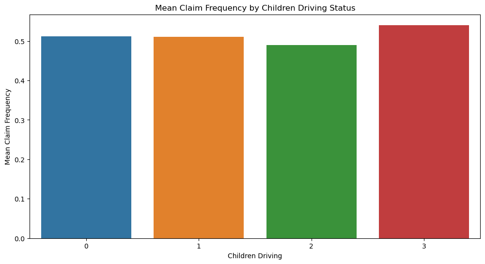

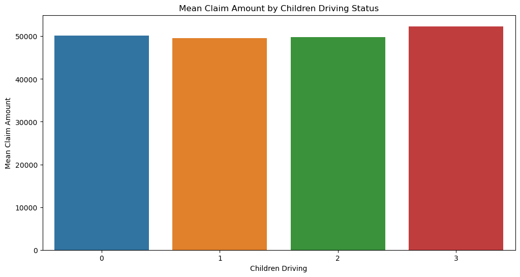

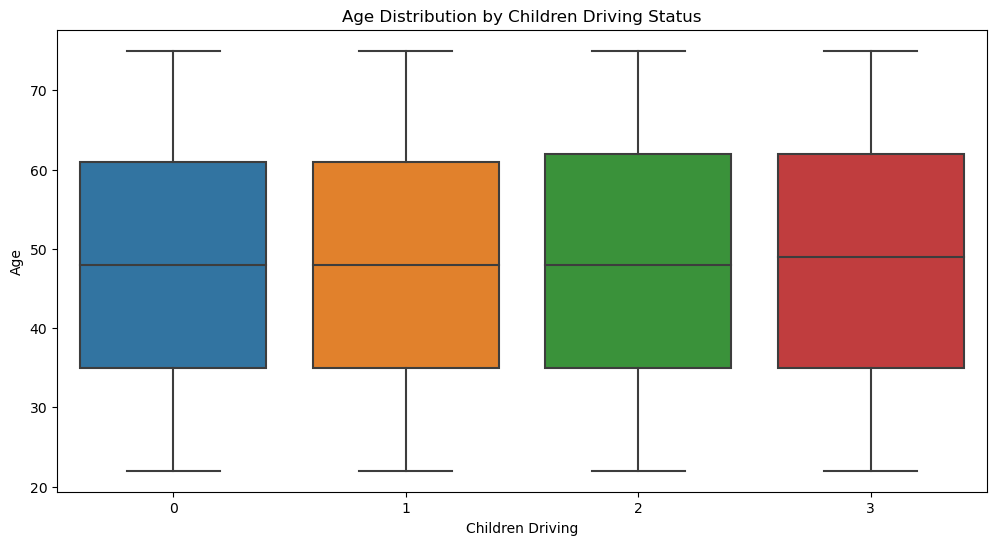

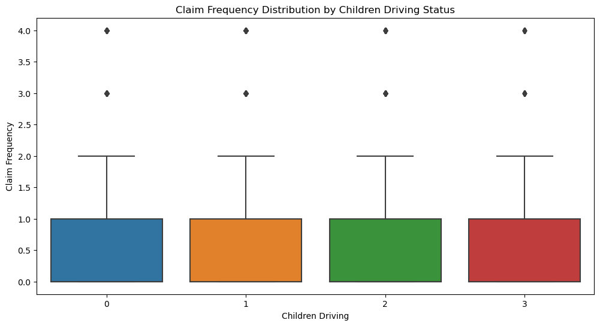

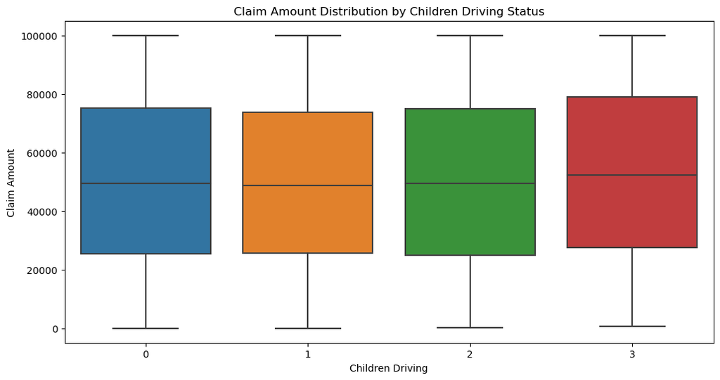

```python
#Visualization of the distribution

# Plot mean claim frequency by children driving status
plt.figure(figsize=(12, 6))
sns.barplot(x='kids_driving', y='mean_claim_freq', data=children_driving_stats)
plt.title('Mean Claim Frequency by Children Driving Status')
plt.xlabel('Children Driving')
plt.ylabel('Mean Claim Frequency')
plt.xticks(rotation=0)
plt.show()

# Plot mean claim amount by children driving status
plt.figure(figsize=(12, 6))
sns.barplot(x='kids_driving', y='mean_claim_amt', data=children_driving_stats)
plt.title('Mean Claim Amount by Children Driving Status')
plt.xlabel('Children Driving')
plt.ylabel('Mean Claim Amount')
plt.xticks(rotation=0)
plt.show()

# Plot age distribution by children driving status
plt.figure(figsize=(12, 6))
sns.boxplot(x='kids_driving', y='age', data=df)
plt.title('Age Distribution by Children Driving Status')
plt.xlabel('Children Driving')
plt.ylabel('Age')
plt.xticks(rotation=0)
plt.show()

# Plot claim frequency distribution by children driving status
plt.figure(figsize=(12, 6))
sns.boxplot(x='kids_driving', y='claim_freq', data=df)
plt.title('Claim Frequency Distribution by Children Driving Status')
plt.xlabel('Children Driving')
plt.ylabel('Claim Frequency')
plt.xticks(rotation=0)
plt.show()

# Plot claim amount distribution by children driving status
plt.figure(figsize=(12, 6))
sns.boxplot(x='kids_driving', y='claim_amt', data=df)
plt.title('Claim Amount Distribution by Children Driving Status')
plt.xlabel('Children Driving')
plt.ylabel('Claim Amount')
plt.xticks(rotation=0)
plt.show()
```

Those with 3 kids have a higher claim frequency amd claim amount distribution

#### 8. How does the presence of children driving affect the frequency and number of claims?

```python
# T-test for claim frequency

from scipy.stats import ttest_ind

# Separate data into groups
group_with_kids = df[df['kids_driving'] > 0]['claim_freq']
group_without_kids = df[df['kids_driving'] == 0]['claim_freq']

# Perform t-test
t_stat, p_value = ttest_ind(group_with_kids, group_without_kids)
print(f'T-test for Claim Frequency: t-statistic = {t_stat}, p-value = {p_value}')


#Critical value
n1 = (df['kids_driving'] > 0).sum()
n2 = (df['kids_driving'] == 0).sum()
alpha = 0.05
dof = n1 + n2 - 2
critical_value = stats.t.ppf(1 - alpha / 2, dof)
print(f'The critical value for the t-test at alpha = {alpha} and dof = {dof} is: {critical_value}')
```

```
T-test for Claim Frequency: t-statistic = -0.49813375766910983, p-value = 0.6183926865748199
The critical value for the t-test at alpha = 0.05 and dof = 37540 is: 1.9600271797030413
```

The t-test for claim frequency shows that the presence of kids does not affect the claim frequeny

```python
#T-test for claim amount

# Separate data into groups
group_with_kids_amt = df[df['kids_driving'] > 0]['claim_amt']
group_without_kids_amt = df[df['kids_driving'] == 0]['claim_amt']

# Perform t-test
t_stat_amt, p_value_amt = ttest_ind(group_with_kids_amt, group_without_kids_amt)
print(f'T-test for Claim Amount: t-statistic = {t_stat_amt}, p-value = {p_value_amt}')

#Critical value
n1 = (df['kids_driving'] > 0).sum()
n2 = (df['kids_driving'] == 0).sum()
alpha = 0.05
dof = n1 + n2 - 2
critical_value = stats.t.ppf(1 - alpha / 2, dof)
print(f'The critical value for the t-test at alpha = {alpha} and dof = {dof} is: {critical_value}')
```

```
T-test for Claim Amount: t-statistic = -0.8362472799449246, p-value = 0.40302112787337296
The critical value for the t-test at alpha = 0.05 and dof = 37540 is: 1.9600271797030413
```

The t-test for claim amount shows that the presence of kids does not affect the claim amount